# Projet

Marc XU

1 Février 2019

```r
setwd("./../Marc")
getwd()
```

```
## [1] "/home/sdv/l3bi/mxu/stage_r/stageL3_2018-master/Marc"
```

# 1 Projet de stage

## 1.1 Partie 1 : Réalisation d’un jeu de données “utilisable”

### 1.1.1 Lecture des jeux de données

```r
donnees1 <- read.csv("../data/placenta_edragon_91mol.csv", header=TRUE, sep=";")
donnees2 <- read.csv("../data/placenta_MOE_2D_192.csv", header=TRUE, sep=";")

clairance <- donnees2[,"CI"]
new_table <- data.frame(donnees1, clairance)
```

Il y a deux jeux de données, dans lequel nous utiliserons le fichier “placenta edragon”.

Nous allons extraire les données de la clairance dans le second fichier “placenta MOE” où nous allons l’ajouter aux données de “placenta edragon”

### 1.1.2 Vérification des jeux de données

**Attention**

```r
ligne_nom <- donnees1[,"NOM"]
ligne_nom2 <- donnees2[, "Noms"]

comparaison <- ligne_nom %in% ligne_nom2
# comparaison
```

**La fonction %in% ne permet que de vérifier si le contenu de deux vecteurs sont-ils identiques, sans vérifier s’ils sont dans le même ordre.**

L’importance de vérifier si les colonnes correspondent aux noms des espèces est identique et dans le même ordre sert à pouvoir utiliser les données dans une des fichiers et de pouvoir l’utiliser dans l’autre.

### 1.1.3 Dimensions du jeu de données

```r
dim(new_table)
```

```
## [1]  91 801
```

### 1.1.4 Colonnes et Lignes

```r
col.nom <- colnames(new_table)
# col.nom
```

```r
rownames(new_table) = new_table$NOM
new_table <- new_table[,-c(1,2)]
```

## 1.2 Partie 2 : Regarder les données

### 1.2.1 Vérification de valeurs aberrantes dans la clairance

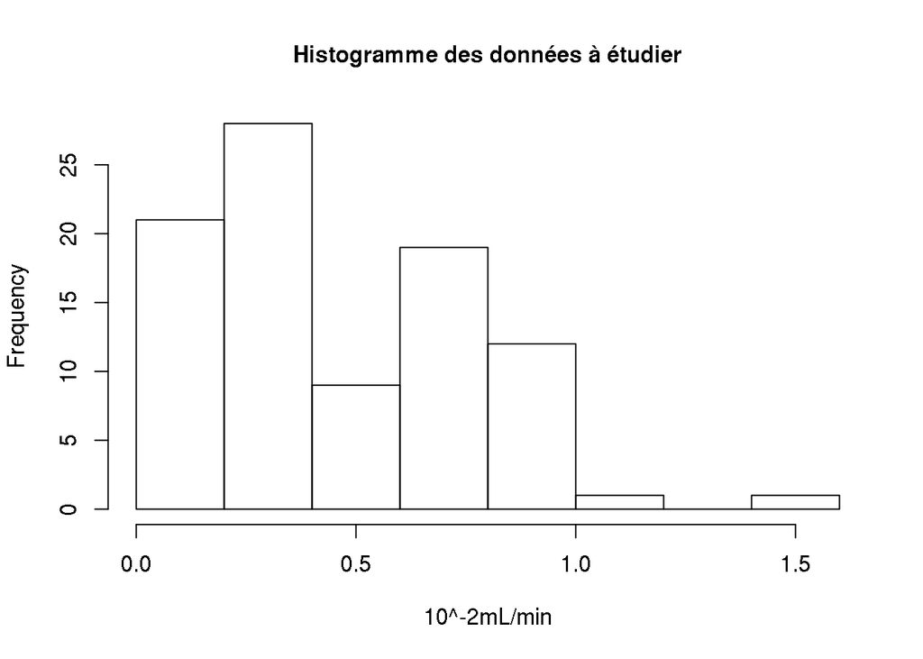

```r
hist(new_table[,"clairance"],
     xlab = "10^-2mL/min",
     main = "Histogramme des données à étudier")
```

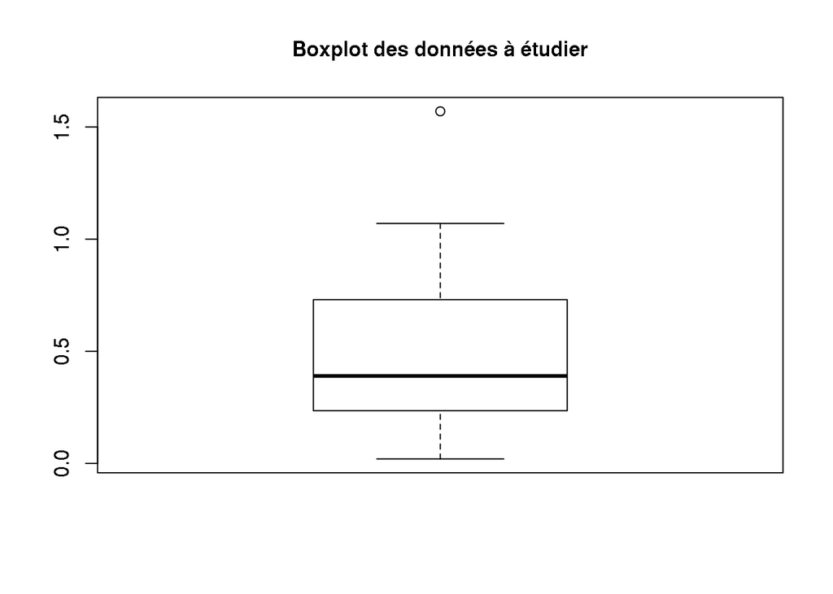

```r
box1 = boxplot(new_table[,"clairance"],
     main = "Boxplot des données à étudier")
```

```r
valeur_out <- box1$out
```

Sur l’histogramme, on peut voir qu’il y a une valeur qui est très différentes des autres. La grande partie des valeurs sont compris entre 0.0 et 1.0 10^-2mL/min, seule une valeur ait 1.5 10^-2mL/min.

Sur le boxplot, cette valeur est en dehors de la valeur maximale du boxplot. C’est une valeur aberrante, car elle pourrait modifier le jeu de données bien qu’elle soit une vraie valeur. Le boxplot vient confirmer l’analyse sur l’histogramme.

```r
new_table$clairance[new_table$clairance == valeur_out] <- NA
new_table = na.omit(new_table)
```

On remplace la valeur aberrante par “NA”, et on l’enlève de la ligne

### 1.2.2 Données manquantes

Dans certaines données, il y a des valeurs manquantes qu’on ne peut pas traiter et sont remplacés par -999. SI une colonne contenant au moins une valeur manquante, alors il faudra supprimer la colonne.

```r
new_table[new_table == -999] <- NA
val_manq = apply(new_table, 2, function(new_table) sum(is.na(new_table)))
# val_manq # Permet de voir le nombre de NA dans chaque colonne

val_non_manq = which(val_manq == 0)
new_table = new_table[, val_non_manq]
```

On peut observer dans chaque colonne, le nombre total de valeurs manquantes.

On peut voir que pour les colonnes : U.045 / U.080 / U.105 / U.113 / U.114. Toutes la colonne n’a pas de données. Il y a d’autres colonnes, où il y a quelques valeurs présentes, mais il reste encore beaucoup de valeurs manquantes : qpmax / qnmax / Qpos / Qneg / Qtot / Qmean /Q2 /RPCG / RNCG / SPP / TE1 / TE2 / PCWTe / LDI.

#### 1.2.2.1 Notes

- which(, arr.ind) : Nous n’avons pas réussi à utiliser la fonction “which”, cependant nous avons trouvé un intermédiaire pour remplacer les valeurs manquantes par NA.

```r
# Bouble "for" qui cherche les colonnes où les valeurs manquantes sont supérieurs à un certain seuil.

for (i in nrow(val_manq):1) {
  val = val_manq[i,1];
  if (val>=5)
  {
    new_table = new_table[, -i];
    #cat(i, val, "\n") # cat permet d'afficher le contenu, comme un printf
  }
}
```

### 1.2.3 Valeurs constantes

```r
var.table <- apply(new_table[,1:780], MARGIN = 2, FUN = var)

toRm <- which(var.table == 0)
toKeep <- which(var.table > 0)
new_table = new_table[,toKeep]
```

Ici, nous voulons supprimer les colonnes où leur variance est nulle, c’est-à-dire des valeurs constantes pour tous les individus.

Nous allons calculer la variance avec la fonction “apply”. Puis nous garderons que les colonnes n’ayant pas de valeurs constantes

### 1.2.4 Dimensions

Les dimensions des jeux de données après relecture : il y a 90 lignes et 605 colonnes.

```r
dim(new_table)
```

[output not shown]

```r
# summary(new_table)
```